# Field Experiment Analysis

Bodo Winter

7/30/2019

## Preliminaries

Load packages:

```r
library(tidyverse) # for data wrangling
library(ade4) # for Mantel tests (correlations of confusion matrices)
```

Load data:

```r
field <- read_csv('../data/field_cleaned.csv')
```

Load ggplot2 theme:

```r
source('theme_timo.R')
```

## Demographics and participant N to report

How many speakers?

```r
length(unique(field$ID))
```

```
## [1] 143
```

```r
table(filter(field, !duplicated(ID))$Sex)
```

```
##
##  f  m
## 99 44
```

```r
# Average age:

mean(filter(field, !duplicated(ID))$Age)
```

```
## [1] 27.52448
```

```r
# Age range:

range(filter(field, !duplicated(ID))$Age)
```

```
## [1] 19 75
```

From 19 to 75.

How many per language?

```r
table(filter(field, !duplicated(ID))$Name)
```

```
##
##           Daakie          English           German          Palikur
##               12               72               19                7
##       Portuguese Tashlhiyt Berber
##               13               20
```

For double-checking codes (“Language”) against names (“Name”):

```r
filter(field, !duplicated(Language))
```

```
## # A tibble: 7 x 14
##   ID    Language   Age Sex   Meaning Team  UniqueItem Choice   ACC Name
##   <chr> <chr>    <dbl> <chr> <chr>   <chr> <chr>      <chr>  <dbl> <chr>
## 1 DE01  DE          48 f     meat    KR    KR_meat.w… water      0 Germ…
## 2 SR01  SR          49 f     meat    KR    KR_meat.w… rock       0 Port…
## 3 VA01  VA          35 m     meat    KR    KR_meat.w… tiger      0 Daak…
## 4 BE01  BE          19 f     meat    KR    KR_meat.w… deer       0 Engl…
## 5 BR01  BR          20 m     meat    KR    KR_meat.w… tiger      0 Tash…
## 6 US02  US          19 m     meat    KR    KR_meat.w… tiger      0 Engl…
## 7 PA01  PA          24 f     meat    KR    KR_meat.w… deer       0 Pali…
## # … with 4 more variables: Name2 <chr>, category <chr>, subcategory <chr>,
## #   Animacy <chr>
```

- DE German
- SR Portuguese (Brazil by Sabine)
- VA Port Vato: Daakie (Vanuatu)
- BE British English
- BR Tashlhiyt Berber
- US American English
- PA Palikur (French Guayana by Sabine)

Check the two Englishes in terms of overall accuracy:

```r
filter(field, Language %in% c('BE', 'US')) %>%
  group_by(Language) %>%
  summarize(ACC = mean(ACC))
```

```
## # A tibble: 2 x 2
##   Language   ACC
##   <chr>    <dbl>
## 1 BE       0.604
## 2 US       0.585
```

## Descriptive statistics

Check overall accuracy across languages:

```r
str_c(round(mean(field$ACC), 2) * 100, '%')
```

```
## [1] "55%"
```

In comparison, chance is:

```r
str_c(round(1/12, 2) * 100, '%')
```

```
## [1] "8%"
```

Check accuracy by language:

```r
lang_avgs <- field %>% group_by(Language, Name) %>%
  summarize(ACC = mean(ACC)) %>%
  arrange(desc(ACC))

# Check:

lang_avgs %>% print(n = Inf)
```

```
## # A tibble: 7 x 3
## # Groups:   Language [7]
##   Language Name               ACC
##   <chr>    <chr>            <dbl>
## 1 DE       German           0.631
## 2 BE       English          0.604
## 3 US       English          0.585
## 4 BR       Tashlhiyt Berber 0.571
## 5 VA       Daakie           0.426
## 6 PA       Palikur          0.373
## 7 SR       Portuguese       0.338
```

Check accuracy by item:

```r
item_avgs <- field %>% group_by(Meaning, subcategory) %>%
  summarize(ACC = mean(ACC)) %>%
  arrange(desc(ACC))

# Check:

item_avgs %>% print(n = Inf)
```

```
## # A tibble: 12 x 3
## # Groups:   Meaning [12]
##    Meaning subcategory   ACC
##    <chr>   <chr>       <dbl>
##  1 child   people      0.855
##  2 tiger   animal      0.846
##  3 man     people      0.809
##  4 snake   animal      0.685
##  5 deer    animal      0.618
##  6 water   inanimate   0.534
##  7 woman   people      0.480
##  8 rock    inanimate   0.434
##  9 knife   inanimate   0.374
## 10 fire    inanimate   0.362
## 11 meat    inanimate   0.333
## 12 fruit   inanimate   0.275
```

Check accuracy by meaning subcategories:

```r
field %>% group_by(subcategory) %>%
  summarize(ACC = mean(ACC)) %>%
  arrange(desc(ACC)) %>%
  print(n = Inf)
```

```
## # A tibble: 3 x 2
##   subcategory   ACC
##   <chr>       <dbl>
## 1 animal      0.716
## 2 people      0.715
## 3 inanimate   0.385
```

“People” and “animal” are almost exactly the same. For the purposes of this analysis, we can lump “people” and “animal” together as “animate”, which is in the “Animacy column”:

```r
# Compute averages:

animacy_avgs <- field %>% group_by(Animacy) %>%
  summarize(ACC = mean(ACC))

# Check:

animacy_avgs
```

```
## # A tibble: 2 x 2
##   Animacy     ACC
##   <chr>     <dbl>
## 1 animate   0.716
## 2 inanimate 0.385
```

Recompute item averages with animacy information, which is only used for plotting later:

```r
item_avgs <- field %>% group_by(Meaning, Animacy) %>%
  summarize(ACC = mean(ACC)) %>%
  arrange(desc(ACC))
```

Check accuracy by team:

```r
field %>% group_by(Team) %>%
  summarize(ACC = mean(ACC)) %>%
  arrange(desc(ACC)) %>%
  print(n = Inf)
```

```
## # A tibble: 7 x 2
##   Team    ACC
##   <chr> <dbl>
## 1 NC    0.744
## 2 SU    0.702
## 3 BW    0.569
## 4 KR    0.547
## 5 IL    0.514
## 6 KD    0.449
## 7 GB    0.446
```

Accuracy by speaker:

```r
speaker_avgs <- field %>% group_by(ID, Language, Sex, Age) %>%
  summarize(ACC = mean(ACC)) %>%
  arrange(desc(ACC)) %>%
  print(n = Inf)
```

```
## # A tibble: 143 x 5
## # Groups:   ID, Language, Sex [143]
##     ID    Language Sex     Age   ACC
##     <chr> <chr>    <chr> <dbl> <dbl>
##   1 DE04  DE       f        47 0.889
##   2 DE18  DE       f        23 0.861
##   3 DE11  DE       f        40 0.806
##   4 US24  US       m        21 0.806
##   5 BE51  BE       f        19 0.778
##   6 BR19  BR       f        23 0.778
##   7 DE09  DE       f        47 0.778
##   8 DE13  DE       f        20 0.778
##   9 DE20  DE       f        21 0.778
##  10 BE21  BE       f        20 0.75
##  11 BE31  BE       f        19 0.75
```

[output cut: 132 more lines]

```r
# Check:

sum(speaker_avgs > 1/12) / nrow(speaker_avgs)
```

[output not shown]

All speakers above chance!

Check accuracy by gender:

```r
speaker_avgs %>% group_by(Sex) %>%
  summarize(ACC = mean(ACC))
```

```
## # A tibble: 2 x 2
##   Sex     ACC
##   <chr> <dbl>
## 1 f     0.571
## 2 m     0.503
```

Check accuracy by age:

```r
# Correlation value:

with(speaker_avgs, cor(Age, ACC, method = 'spearman'))
```

```
## [1] -0.3359454
```

Older speakers are worse. Of course, one should be careful in interpreting this correlation, as the different languages have different overall ages, i.e., language is conflated with age:

```r
speaker_avgs %>% group_by(Language) %>%
  summarize(Age = mean(Age))
```

```
## # A tibble: 7 x 2
##   Language   Age
##   <chr>    <dbl>
## 1 BE        19.7
## 2 BR        22.4
## 3 DE        42
## 4 PA        24.7
## 5 SR        47.5
## 6 US        19.2
## 7 VA        40.8
```

## Marcus’s descriptive statistics: how many meanings per language above chance?

A simple way to summarize this data is to check how many meanings are guessed above chance per language.

First, let’s get a vector with the language names which we’ll use for looping:

```r
languages <- unique(field$Language)

# Check:

languages
```

```
## [1] "DE" "SR" "VA" "BE" "BR" "US" "PA"
```

Put this into a tibble:

```r
meanings_per_language <- tibble(Language = languages)
meanings_per_language$N_over_chance <- NA

# Check:

meanings_per_language
```

```
## # A tibble: 7 x 2
##   Language N_over_chance
##   <chr>    <lgl>
## 1 DE       NA
## 2 SR       NA
## 3 VA       NA
## 4 BE       NA
## 5 BR       NA
## 6 US       NA
## 7 PA       NA
```

Loop through languages and get the N of items that have > 1/12 accuracy:

```r
for (i in seq_along(languages)) {
  this_lang <- languages[i]
  these_avgs <- filter(field, Language == this_lang) %>%
    group_by(Meaning) %>%
    summarize(ACC = mean(ACC))
  meanings_per_language[i, ]$N_over_chance <- sum(these_avgs$ACC > 1/12)
}
```

Check the results:

```r
meanings_per_language
```

```
## # A tibble: 7 x 2
##   Language N_over_chance
##   <chr>            <int>
## 1 DE                  12
## 2 SR                  10
## 3 VA                  12
## 4 BE                  12
## 5 BR                  12
## 6 US                  12
## 7 PA                  10
```

## Publication-ready plots:

Accuracy across languages:

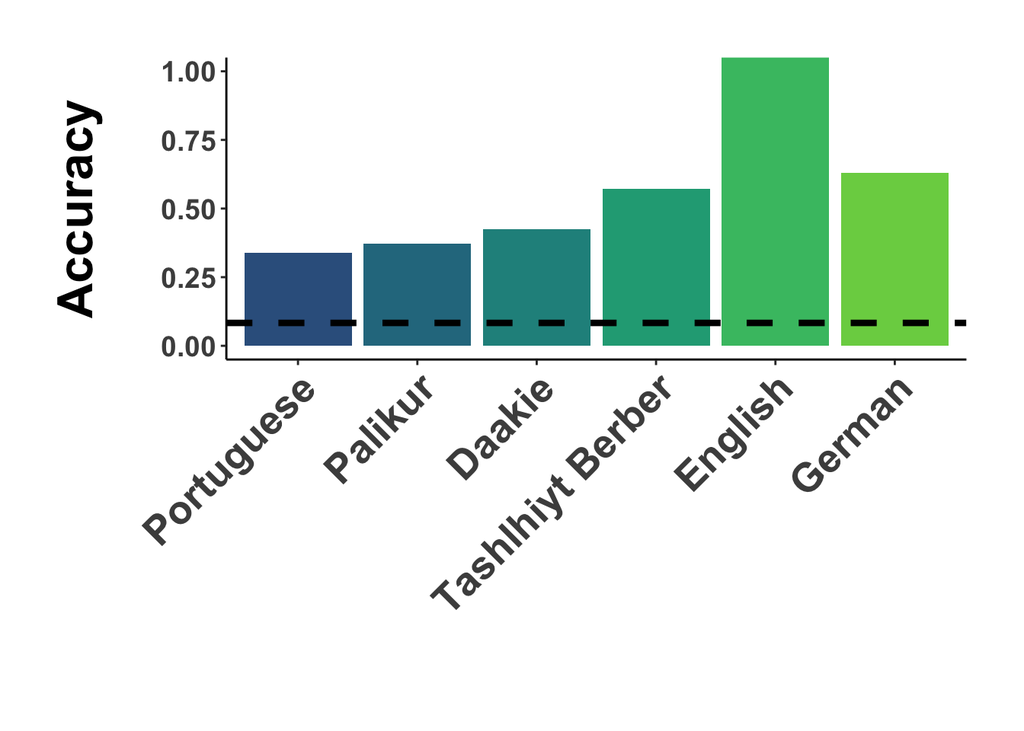

```r
lang_avgs %>%
  ggplot(aes(x = reorder(Name, ACC),
             y = ACC, fill = reorder(Name, ACC))) +
  geom_col() +
  geom_hline(yintercept = 1 / 12, linetype = 2, size = 1.5) +
  labs(x = '', y = 'Accuracy\n') +
  scale_fill_viridis_d(option = 'D', begin = 0.3, end = 0.8) +
  theme_timo +
  coord_cartesian(ylim = c(0, 1.0)) +
  theme(axis.text.x = element_text(angle = 45, hjust = 1, face = 'bold', size = 20),
        axis.text.y = element_text(face = 'bold', size = 14),
        axis.title = element_text(face = 'bold', size = 24),
        legend.position = 'none')
```

```r
ggsave('../figures/field_languages.png', width = 8, height = 6)
```

Accuracy across languages, with BE and AE differentiated:

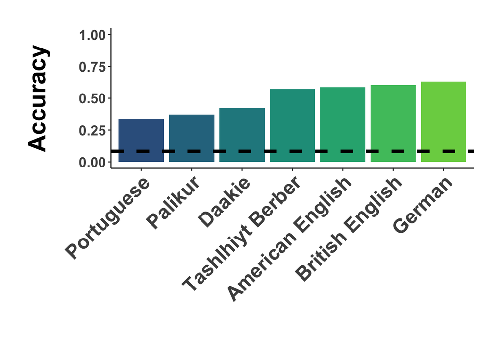

```r
field %>% group_by(Name2) %>%
  summarize(ACC = mean(ACC)) %>%
  arrange(desc(ACC)) %>%
  ggplot(aes(x = reorder(Name2, ACC),
             y = ACC, fill = reorder(Name2, ACC))) +
  geom_col() +
  geom_hline(yintercept = 1 / 12, linetype = 2, size = 1.5) +
  labs(x = '', y = 'Accuracy\n') +
  scale_fill_viridis_d(option = 'D', begin = 0.3, end = 0.8) +
  theme_timo +
  coord_cartesian(ylim = c(0, 1.0)) +
  theme(axis.text.x = element_text(angle = 45, hjust = 1, face = 'bold', size = 20),
        axis.text.y = element_text(face = 'bold', size = 14),
        axis.title = element_text(face = 'bold', size = 24),
        legend.position = 'none')
```

```r
ggsave('../figures/field_languages_AE_vs_BE.png', width = 8, height = 6)
```

Accuracy across items:

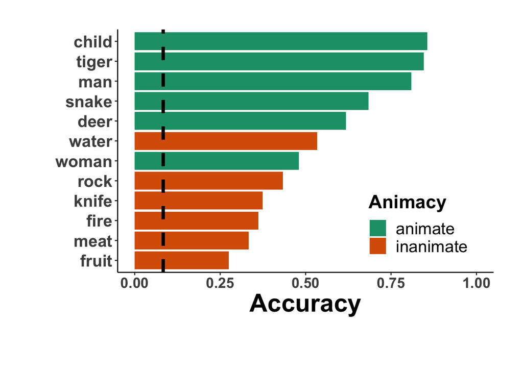

```r
item_avgs %>%
  ggplot(aes(x = reorder(Meaning, ACC),
             y = ACC,
             fill = Animacy)) +
  geom_col() +
  geom_hline(yintercept = 1 / 12, linetype = 2, size = 1.5) +
  labs(x = '', y = 'Accuracy\n') +
  scale_fill_brewer(palette = 'Dark2') +
  theme_timo +
  ylim(0, 1.0) +
  theme(axis.text.x = element_text(face = 'bold', size = 14),
        axis.text.y = element_text(face = 'bold', size = 16),
        axis.title = element_text(face = 'bold', size = 24),
        legend.position = c(0.8, 0.2)) +
  coord_flip()
```

```r
ggsave('../figures/field_items.png', width = 12, height = 12)
```

## Confusion matrices:

Check confusion, first for English:

```r
EN <- filter(field, Language == 'EN')
EN_tab <- table(EN$Meaning, EN$Choice)
EN_tab
```

```
## < table of extent 0 x 0 >
```

We can re-use the “languages” vector from above for this.

```r
M <- rep(NA, length(languages) * length(languages))
M <- matrix(M, nrow = length(languages))

# Append row and column names:

rownames(M) <- languages
colnames(M) <- languages

# Check:

M
```

```
##    DE SR VA BE BR US PA
## DE NA NA NA NA NA NA NA
## SR NA NA NA NA NA NA NA
## VA NA NA NA NA NA NA NA
## BE NA NA NA NA NA NA NA
## BR NA NA NA NA NA NA NA
## US NA NA NA NA NA NA NA
## PA NA NA NA NA NA NA NA
```

Create two copies of this matrix, one for the correlation coefficients, another one for the p-values:

```r
r_vals <- M
p_vals <- M
```

Loop through languages and create distance matrices:

```r
for (i in seq_along(languages)) {
  # Cross-tabulation:

  this_tab <- with(filter(field, Language == languages[i]), table(Meaning, Choice))

  # Transform into distance matrix object (needed for Mantel test):

  this_tab <- as.dist(this_tab)

  # Save this in an object with the name pattern "EN_tab" etc.:

  assign(str_c(languages[i], '_tab'), this_tab)
}
```

Loop through languages and put this information into the corresponding matrices:

```r
for (i in seq_along(languages)) {
  lang1 <- languages[i]
  for (j in seq_along(languages)) {
    lang2 <- languages[j]
    if (lang1 != lang2) {
      # Retrieve previously stored distance matrices:

      tab1 <- get(str_c(languages[i], '_tab'))
      tab2 <- get(str_c(languages[j], '_tab'))

      # Perform correlation:

      this_mantel <- mantel.rtest(tab1, tab2, nrepet = 999)

      # Store correlation value and p-value:

      r_vals[i, j] <- this_mantel$obs
      p_vals[i, j] <- this_mantel$pvalue

    }
  }
}
```

Check results:

```r
## Correlation values:

round(r_vals, 2)
```

```
##      DE   SR   VA   BE   BR   US   PA
## DE   NA 0.67 0.55 0.81 0.52 0.62 0.40
## SR 0.67   NA 0.59 0.68 0.41 0.67 0.41
## VA 0.55 0.59   NA 0.65 0.54 0.44 0.66
## BE 0.81 0.68 0.65   NA 0.71 0.79 0.57
## BR 0.52 0.41 0.54 0.71   NA 0.61 0.49
## US 0.62 0.67 0.44 0.79 0.61   NA 0.44
## PA 0.40 0.41 0.66 0.57 0.49 0.44   NA
```

What’s the minimum and maximum correlation value?

```r
range(r_vals, na.rm = TRUE)
```

```
## [1] 0.3985599 0.8055533
```

What’s the mean correlation?

```r
mean(r_vals, na.rm = TRUE)
```

```
## [1] 0.5818032
```

What are the p-values?:

```r
p_vals
```

```
##       DE    SR    VA    BE    BR    US    PA
## DE    NA 0.001 0.001 0.001 0.002 0.001 0.008
## SR 0.001    NA 0.001 0.001 0.007 0.001 0.003
## VA 0.001 0.001    NA 0.001 0.001 0.002 0.001
## BE 0.001 0.001 0.001    NA 0.001 0.001 0.001
## BR 0.001 0.010 0.001 0.001    NA 0.001 0.001
## US 0.001 0.001 0.002 0.001 0.001    NA 0.001
## PA 0.003 0.002 0.001 0.001 0.001 0.001    NA
```

This completes this analysis.